# 411B Advisor Emails

## SUBJECT

MEDS Capstone Updates - Spring Week X

## Previous emails

https://docs.google.com/document/d/1w3Efx8n2jHzPfC6P0Sfovc–FtqOgYyG8h7HEK0f0bQ/edit?tab=t.0

## Previous bullet points

### Week 7

- As a reminder, students developed a Team Management Plan during the fall as part of their Design and Implementation Plan. You can encourage them to revisit this document, as well as the materials from their workshop with the Associated Ombuds on managing conflict and fostering healthy team dynamics.

## Week 1

Hi MEDS Capstone Advisors,

I hope you had a re-energizing Spring break and your quarter is off to a great start!

I’m looking forward to keeping working together as students advance on their capstone projects. Like last quarter, I’ll send you a weekly email with updates about what we’re covering in the MEDS Capstone Course 411B and reminders of upcoming deadlines. This one is a bit late as you’ll normally receive it Mondays.

Please don’t hesitate to reach out with any questions, comments, or suggestions.

Best wishes,

Carmen

Carmen Galaz García | Assistant Teaching Professor  
Bren School of Environmental Science and Management  
University of California, Santa Barbara  
(she / her / hers)

[EDS 411 Course website](https://meds-eds-411.github.io/eds-411-website/)

[Capstone guidelines](https://bren.ucsb.edu/sites/default/files/Capstone%20Project%20Guidelines%20MEDS%202026.pdf)

Upcoming Major Deadlines

Advisor Check-ins

In 411B this week [(slides @ website)](https://meds-eds-411.github.io/eds-411-website/411b_spring/411b_week1.html)

- We covered an overview of EDS 411B, this quarter’s timeline, and the spring quarter deliverables.
- We covered details about the Technical Documentation and its sections. Students read the corresponding information in the Capstone Guidelines.
- Students worked independently with their capstone team and I checked in with each team.

Tasks all groups are expected to complete before next 411B class:

- Write down a detailed list of the sections (table of contents) for their Technical Documentation (TD), specifying who is the target audience for each section or groups of sections.
- Write down a timeline to completion for the Technical Documentation.
- Write down information for their executive summary about the background, motivation, problem statement, objectives, and deliverables.
- Revise the project timeline they submitted in the DIP and discuss major changes with their advisor.

## Week 2

Hello MEDS Capstone Advisors,

This is your weekly EDS 411 - MEDS Capstone project newsletter.

Please don’t hesitate to reach out with any questions, comments, or suggestions.

Best wishes,

Carmen

Carmen Galaz García | Assistant Teaching Professor  
Bren School of Environmental Science and Management  
University of California, Santa Barbara  
(she / her / hers)

[EDS 411 Course website](https://meds-eds-411.github.io/eds-411-website/)

[Capstone guidelines](https://bren.ucsb.edu/sites/default/files/Capstone%20Project%20Guidelines%20MEDS%202026.pdf)

Upcoming Major Deadlines

Advisor Check-ins

- As students re-engage with their projects, clarifying deliverables can help set direction. Please help teams align on what they are working toward.
- Weeks 2 - 4 are very light on official capstone deadlines. Teams should use this time to prioritize their project implementation!

In 411B this week [(slides @ website)](https://meds-eds-411.github.io/eds-411-website/411b_spring/411b_week2.html)

- Teams received peer feedback on an outline for their Technical Documentation.
- Students worked independently with their capstone team and I checked in with each team.

Tasks all groups are expected to complete before next 411B class:

- Expand TD outline into preliminary draft.
- Continue working on project implementation.

## Week 3

Hello MEDS Capstone Advisors,

This is your weekly EDS 411 - MEDS Capstone project newsletter.

Please don’t hesitate to reach out with any questions, comments, or suggestions.

Best wishes,

Carmen

Carmen Galaz García | Assistant Teaching Professor  
Bren School of Environmental Science and Management  
University of California, Santa Barbara  
(she / her / hers)

[EDS 411 Course website](https://meds-eds-411.github.io/eds-411-website/)

[Capstone guidelines](https://bren.ucsb.edu/sites/default/files/Capstone%20Project%20Guidelines%20MEDS%202026.pdf)

Upcoming Major Deadlines

Advisor Check-ins

> Each section of the preliminary draft must include as much information as completed to date. Clearly indicated placeholders or bulleted lists are acceptable at this point. An appendix to the preliminary draft should describe the work to be completed during the remainder of Spring Quarter, any remaining obstacles to its completion, and a timeline for remaining tasks and deliverables.
- As you review your team’s TD, please take the following into account:
  - Pages 24-33 of the Capstone Guidelines have extensive details about what is expected on each section of the Technical Documentation.
  - Please encourage students to be specific and detailed.
  - The TD format is flexible, so if you feel aspects of the project are not being communicated clearly, feel free to suggest restructuring.
  - Encourage your team to report values and include formulas, figures, and tables to communicate the project’s methods and results.

In 411B this week [(slides @ website)](https://meds-eds-411.github.io/eds-411-website/411b_spring/411b_week3.html)

- Students shared 1-on-1 across teams questions, challenges, or decisions they wanted input on and discussed these
- Students worked independently with their capstone team and I checked in with each team.

Tasks all groups are expected to complete before next 411B class:

- Submit Technical Documentation preliminary draft
- Continue working on the project’s implementation!

## Week 4

Hello MEDS Capstone Advisors,

I hope you are doing great.

This is your weekly EDS 411 - MEDS Capstone project newsletter. Please don’t hesitate to reach out with any questions, comments, concerns, or suggestions.

Best wishes,

Carmen

Carmen Galaz García | Assistant Teaching Professor  
Bren School of Environmental Science and Management  
University of California, Santa Barbara  
(she / her / hers)

[EDS 411 Course website](https://meds-eds-411.github.io/eds-411-website/)

[Capstone guidelines](https://bren.ucsb.edu/sites/default/files/Capstone%20Project%20Guidelines%20MEDS%202026.pdf)

Upcoming Major Deadlines

Advisor Check-ins

> Each section of the preliminary draft must include as much information as completed to date. Clearly indicated placeholders or bulleted lists are acceptable at this point. An appendix to the preliminary draft should describe the work to be completed during the remainder of Spring Quarter, any remaining obstacles to its completion, and a timeline for remaining tasks and deliverables.
- As you review your team’s TD, please take the following into account:
  - Pages 24-33 of the Capstone Guidelines have extensive details about what is expected on each section of the Technical Documentation.
  - Please encourage students to be specific and detailed.
  - The documentation format is flexible, so if you feel aspects of the project are not being communicated clearly, feel free to suggest restructuring.
  - Encourage your team to report values and include formulas, figures, and tables to communicate the project’s methods and results.

In 411B this week [(slides @ website)](https://meds-eds-411.github.io/eds-411-website/411b_spring/411b_week4.html)

- Sam Shanny-Csik presented a workshop on unit testing for web apps
- Students worked independently with their capstone team and I checked in with each team.

Tasks all groups are expected to complete before next 411B class:

- Update their GitHub organization and repositories
- Continue working on the project’s implementation!

## Week 5

Hello MEDS Capstone Advisors,

This is your weekly EDS 411 - MEDS Capstone project newsletter. Please don’t hesitate to reach out with any questions, comments, concerns, or suggestions.

Best wishes!

Carmen

Carmen Galaz García | Assistant Teaching Professor  
Bren School of Environmental Science and Management  
University of California, Santa Barbara  
(she / her / hers)

[EDS 411 Course website](https://meds-eds-411.github.io/eds-411-website/)

[Capstone guidelines](https://bren.ucsb.edu/sites/default/files/Capstone%20Project%20Guidelines%20MEDS%202026.pdf)

Upcoming Major Deadlines

Advisor Check-ins

- Thanks for providing feedback on your team’s Technical Documentation! I’ve heard from several teams that they really appreciate the input at this draft stage so they can implement changes and dive deeper into their project with enough time.
- In two weeks, students will start preparing their final presentations. Students should take advantage of this week and the next to make significant progress on their deliverables and technical documentation.

In 411B this week [(slides @ website)](https://meds-eds-411.github.io/eds-411-website/411b_spring/411b_week5.html)

- Teams received peer feedback on their GitHub Organization and Repositories.
- Students worked independently with their capstone team and I checked in with each team.

Tasks all groups are expected to complete before next 411B class:

- Completing a mid-quarter personal reflection
- Confirm the final title for their capstone project
- Work on incorporating feedback to their Technical Documentation
- Update their GitHub organization and repositories
- Make significant progress on their capstone deliverables!

## Week 6

Hello MEDS Capstone Advisors,

This is your weekly EDS 411 - MEDS Capstone project newsletter. Please don’t hesitate to reach out with any questions, comments, concerns, or suggestions.

Best wishes!

Carmen

Carmen Galaz García | Assistant Teaching Professor  
Bren School of Environmental Science and Management  
University of California, Santa Barbara  
(she / her / hers)

[EDS 411 Course website](https://meds-eds-411.github.io/eds-411-website/)

[Capstone guidelines](https://bren.ucsb.edu/sites/default/files/Capstone%20Project%20Guidelines%20MEDS%202026.pdf)

Upcoming Major Deadlines

Advisor Check-ins

- We’ll start preparing for public presentations next week. Students should take advantage of this week to make significant progress on their deliverables and technical documentation!
- Students will prepare their first practice presentation for the coming Monday. They may reach out to you for comments on their draft slides.
- Students should discuss with you what data should be archived as part of their project deliverables . They should meet, if necessary, with the Library Research Data Services team before archiving in the Dryad repository. Please check in with students about their data archival plans.

In 411B this week [(slides @ website)](https://meds-eds-411.github.io/eds-411-website/411b_spring/411b_week6.html)

- Alex Phillips, Asst. Teaching Professor @ Bren, led a workshop about *Ten tips to improve presentations*.
- Jamie Montgomery, the MEDS program director, presented the logistics for the faculty reviews.
- Students worked independently with their capstone team and I checked in with each team.

Tasks all groups are expected to complete before next 411B class:

- Prepare final Technical Documentation draft
- Prepare draft 1 of final presentation
- Submit final abstract and acknowledgements
- Initiate data archival
- Make significant progress on their capstone deliverables!

## Week 7

Hello MEDS Capstone Advisors,

This is your weekly EDS 411 - MEDS Capstone project newsletter. Please don’t hesitate to reach out with any questions, comments, concerns, or suggestions.

Best wishes!

Carmen

Carmen Galaz García | Assistant Teaching Professor  
Bren School of Environmental Science and Management  
University of California, Santa Barbara  
(she / her / hers)

[EDS 411 Course website](https://meds-eds-411.github.io/eds-411-website/)

[Capstone guidelines](https://bren.ucsb.edu/sites/default/files/Capstone%20Project%20Guidelines%20MEDS%202026.pdf)

Upcoming Deadlines

Advisor Check-ins

In 411B this week [(slides @ website)](https://meds-eds-411.github.io/eds-411-website/411b_spring/411b_week7.html)

- Each team presented a first draft of their final presentation and received feedback.
- Students worked independently with their capstone team.

Tasks all groups are expected to complete before next 411B class:

- Send links to their updated Technical Documentation draft and GitHub repository to their advisor and 411 instructor
- Prepare abstract and send it for revision to advisors
- Prepare acknowledgements and ask for consent from everyone listed
- Prepare version 2.0 of their final presentation
- Discuss data archival plans with advisor and initiate archival if necessary
- Keep implementing their project

## Week 8

Hello MEDS Capstone Advisors,

This is your weekly EDS 411 - MEDS Capstone project newsletter. Please don’t hesitate to reach out with any questions, comments, concerns, or suggestions.

Best wishes!

Carmen

Carmen Galaz García | Assistant Teaching Professor  
Bren School of Environmental Science and Management  
University of California, Santa Barbara  
(she / her / hers)

[EDS 411 Course website](https://meds-eds-411.github.io/eds-411-website/)

[Capstone guidelines](https://bren.ucsb.edu/sites/default/files/Capstone%20Project%20Guidelines%20MEDS%202026.pdf)

Upcoming Deadlines

Advisor Check-ins

- If you haven’t yet, please review your team’s Technical Documentation *and* GitHub repositories by the end of today.
- Final presentations are next week! Students are working on updating their presentations to practice this Wednesday. Please review your team’s presentation! It makes a huge difference.
- Students will be archiving their data by the end of this week. Please check in with students about their data archival plans if you haven’t already.

In 411B this week [(slides @ website)](https://meds-eds-411.github.io/eds-411-website/411b_spring/411b_week8.html)

- Each team presented a second draft of their final presentation and received feedback.
- Students worked independently with their capstone team.

Tasks all groups are expected to complete before next 411B class:

- Complete data archival
- Submit editable file of closed captioning script
- Prepare a final mock presentation
- Work on updating their Technical Documentation and GitHub materials
- Start finalizing the project deliverables!

## Week 9

Hello MEDS Capstone Advisors,

This is your weekly EDS 411 - MEDS Capstone project newsletter. Please don’t hesitate to reach out with any questions, comments, concerns, or suggestions.

Best wishes!

Carmen

Carmen Galaz García | Assistant Teaching Professor  
Bren School of Environmental Science and Management  
University of California, Santa Barbara  
(she / her / hers)

[EDS 411 Course website](https://meds-eds-411.github.io/eds-411-website/)

[Capstone guidelines](https://bren.ucsb.edu/sites/default/files/Capstone%20Project%20Guidelines%20MEDS%202026.pdf)

Upcoming Deadlines

Advisor Check-ins

- Final presentations are this Friday! All teams have put a lot of work into preparing for this event and their presentations are, generally, in a good place.
- Students will have one final round of practice presentations today. If you haven’t done so, please allocate time during a team meeting for a mock presentation or discussing any final edits to the student’s slides.
- Please join us for a celebratory reception at the Bren courtyard at 4:15 pm after the presentations. It’d be great to see you there! 🎊

In 411B this week [(slides @ website)](https://meds-eds-411.github.io/eds-411-website/411b_spring/411b_week9.html)

- Teams had one final practice at BH 1414, received feedback, and practiced the Q&A.
- Students worked independently with their capstone team.

Tasks all groups are expected to complete before next 411B class:

- Work on wrapping up their projects!
- Make final updates to their Technical Documentation
- Make final updates to GitHub repository

## Week 10

Hello MEDS Capstone Advisors,

This is your weekly EDS 411 - MEDS Capstone project newsletter. Please don’t hesitate to reach out with any questions, comments, concerns, or suggestions.

Best wishes!

Carmen

Carmen Galaz García | Assistant Teaching Professor  
Bren School of Environmental Science and Management  
University of California, Santa Barbara  
(she / her / hers)

[EDS 411 Course website](https://meds-eds-411.github.io/eds-411-website/)

[Capstone guidelines](https://bren.ucsb.edu/sites/default/files/Capstone%20Project%20Guidelines%20MEDS%202026.pdf)

Upcoming Deadlines

Advisor Check-ins

- Covered how to do a GitHub release for their code
- Kat Le went over how to transfer files out of the workbench
- Students completed the MEDS EOY survey
- Teams reflected on learnings through the capstone project, what they still want to improve, and major wins. They summarized their thoughts leaving a message of encouragement and advice to the next MEDS cohort.

Tasks all groups are expected to complete before next 411B class:

- Complete personal reflection & team/self evaluation
- Submit final Technical Documentation and Signature Page
- Send final documentation, GitHub repository, and deliverables to clients
- Complete Faculty Advisor Evaluation
- Complete course surveys

## Finals week

Hi MEDS Capstone Advisors,

This is the last MEDS Capstone project newsletter.

Wishing you all a great summer,

Carmen

Carmen Galaz García | Assistant Teaching Professor  
Bren School of Environmental Science and Management  
University of California, Santa Barbara  
(she / her / hers)

[EDS 411 Course website](https://meds-eds-411.github.io/eds-411-website/)

[Capstone guidelines](https://bren.ucsb.edu/sites/default/files/Capstone%20Project%20Guidelines%20MEDS%202026.pdf)

Advisor Check-ins

- All students submitted all their final academic deliverables last Friday. There is nothing else left to submit to MEDS as an academic requirement.
- You should have received a Peer and Self evaluation form from every student in your group.
- I have emailed you the proposed grades for students in your group. If you have any comments, please let me know by the end of Wednesday. I’m planning to submit grades for EDS 411B on Thursday.
- Your feedback on the MEDS capstone projects is really important to us. We’d greatly appreciate it if you could please take 10 minutes to complete this short anonymous survey:

[Advisor End-of-Year Survey](https://docs.google.com/forms/d/e/1FAIpQLScqxxgFF_r4hYqUO4MoeXVwk0Ud01CR9O9VPD02S9e72AwVfw/viewform?usp=share_link&ouid=111507336322611936333)

Recap

The Capstone Projects are a cornerstone of the MEDS program and one of the top reasons students choose to enroll. These projects simply wouldn’t be possible without your advice and mentorship. So on behalf of the MEDS Capstone Team:

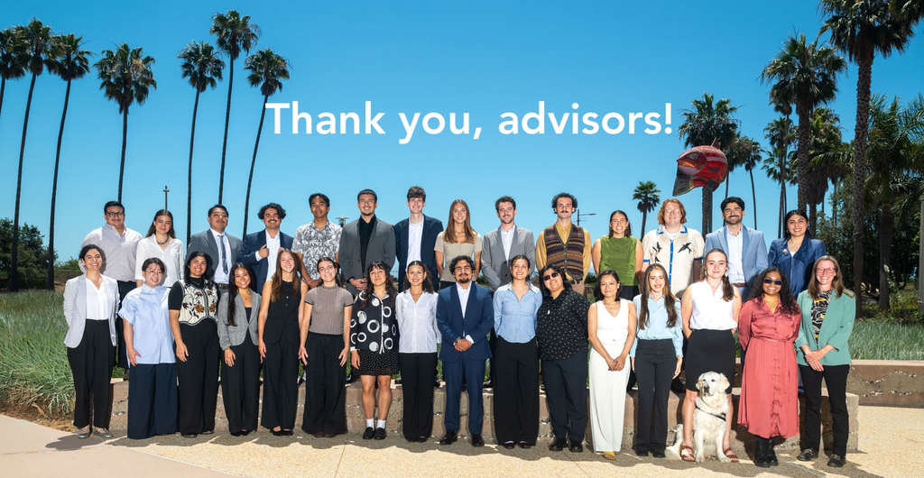

If there are any lingering questions or topics you’d like to chat about, please feel free to reach out.